# Credit Card Users Churn Prediction

## Problem Statement

### Business Context

The Thera bank recently saw a steep decline in the number of users of their credit card, credit cards are a good source of income for banks because of different kinds of fees charged by the banks like annual fees, balance transfer fees, and cash advance fees, late payment fees, foreign transaction fees, and others. Some fees are charged to every user irrespective of usage, while others are charged under specified circumstances.

Customers’ leaving credit cards services would lead bank to loss, so the bank wants to analyze the data of customers and identify the customers who will leave their credit card services and reason for same – so that bank could improve upon those areas

You as a Data scientist at Thera bank need to come up with a classification model that will help the bank improve its services so that customers do not renounce their credit cards

### Data Description

- CLIENTNUM: Client number. Unique identifier for the customer holding the account
- Attrition_Flag: Internal event (customer activity) variable - if the account is closed then "Attrited Customer" else "Existing Customer"
- Customer_Age: Age in Years
- Gender: Gender of the account holder
- Dependent_count: Number of dependents
- Education_Level: Educational Qualification of the account holder - Graduate, High School, Unknown, Uneducated, College(refers to college student), Post-Graduate, Doctorate
- Marital_Status: Marital Status of the account holder
- Income_Category: Annual Income Category of the account holder
- Card_Category: Type of Card
- Months_on_book: Period of relationship with the bank (in months)
- Total_Relationship_Count: Total no. of products held by the customer
- Months_Inactive_12_mon: No. of months inactive in the last 12 months
- Contacts_Count_12_mon: No. of Contacts in the last 12 months
- Credit_Limit: Credit Limit on the Credit Card
- Total_Revolving_Bal: Total Revolving Balance on the Credit Card
- Avg_Open_To_Buy: Open to Buy Credit Line (Average of last 12 months)
- Total_Amt_Chng_Q4_Q1: Change in Transaction Amount (Q4 over Q1)
- Total_Trans_Amt: Total Transaction Amount (Last 12 months)
- Total_Trans_Ct: Total Transaction Count (Last 12 months)
- Total_Ct_Chng_Q4_Q1: Change in Transaction Count (Q4 over Q1)
- Avg_Utilization_Ratio: Average Card Utilization Ratio

#### What Is a Revolving Balance?

- If we don't pay the balance of the revolving credit account in full every month, the unpaid portion carries over to the next month. That's called a revolving balance

##### What is the Average Open to buy?

- 'Open to Buy' means the amount left on your credit card to use. Now, this column represents the average of this value for the last 12 months.

##### What is the Average utilization Ratio?

- The Avg_Utilization_Ratio represents how much of the available credit the customer spent. This is useful for calculating credit scores.

##### Relation b/w Avg_Open_To_Buy, Credit_Limit and Avg_Utilization_Ratio:

- ( Avg_Open_To_Buy / Credit_Limit ) + Avg_Utilization_Ratio = 1

### **Please read the instructions carefully before starting the project.**

This is a commented Jupyter IPython Notebook file in which all the instructions and tasks to be performed are mentioned.

- Blanks '**___**' are provided in the notebook that needs to be filled with an appropriate code to get the correct result. With every '**___**' blank, there is a comment that briefly describes what needs to be filled in the blank space.
- Identify the task to be performed correctly, and only then proceed to write the required code.
- Fill the code wherever asked by the commented lines like "# write your code here" or "# complete the code". Running incomplete code may throw error.
- Please run the codes in a sequential manner from the beginning to avoid any unnecessary errors.
- Add the results/observations (wherever mentioned) derived from the analysis in the presentation and submit the same.

## Importing necessary libraries

```python
from google.colab import drive
drive.mount('/content/drive')
```

```python
# Installing the libraries with the specified version.
# uncomment and run the following line if Google Colab is being used
!pip install scikit-learn==1.2.2 seaborn==0.13.1 matplotlib==3.7.1 numpy==1.25.2 pandas==1.5.3 imbalanced-learn==0.10.1 xgboost==2.0.3 -q --user
```

[output not shown]

```python
# Installing the libraries with the specified version.
# uncomment and run the following lines if Jupyter Notebook is being used
# !pip install scikit-learn==1.2.2 seaborn==0.13.1 matplotlib==3.7.1 numpy==1.25.2 pandas==1.5.3 imblearn==0.12.0 xgboost==2.0.3 -q --user
# !pip install --upgrade -q threadpoolctl
```

**Note**: *After running the above cell, kindly restart the notebook kernel and run all cells sequentially from the start again*.

```python
import numpy as np
import pandas as pd
import matplotlib.pyplot as plt
import seaborn as sns
from sklearn.tree import DecisionTreeClassifier
from sklearn.model_selection import train_test_split
from sklearn.metrics import confusion_matrix, classification_report
from sklearn.metrics import accuracy_score,precision_score,recall_score,f1_score
import scipy.stats as stats
from sklearn import metrics
from sklearn import tree
from sklearn.model_selection import GridSearchCV
from sklearn.ensemble import BaggingClassifier
from sklearn.ensemble import RandomForestClassifier
from sklearn.metrics import roc_auc_score
import warnings
warnings.filterwarnings('ignore')


from sklearn.ensemble import BaggingRegressor,RandomForestRegressor, GradientBoostingRegressor, AdaBoostRegressor, StackingRegressor
from xgboost import XGBRegressor
from sklearn import metrics
from sklearn.model_selection import GridSearchCV, train_test_split
```

## Loading the dataset

```python
df = pd.read_csv("/content/drive/MyDrive/Colab Notebooks/BankChurners.csv")
```

## Data Overview

- Observations
- Sanity checks

### Viewing the first 5 rows of the dataset

```python
df.head()
```

|  | CLIENTNUM | Attrition_Flag | Customer_Age | Gender | Dependent_count | Education_Level | Marital_Status | Income_Category | Card_Category | Months_on_book | ... | Months_Inactive_12_mon | Contacts_Count_12_mon | Credit_Limit | Total_Revolving_Bal | Avg_Open_To_Buy | Total_Amt_Chng_Q4_Q1 | Total_Trans_Amt | Total_Trans_Ct | Total_Ct_Chng_Q4_Q1 | Avg_Utilization_Ratio |
| --- | --- | --- | --- | --- | --- | --- | --- | --- | --- | --- | --- | --- | --- | --- | --- | --- | --- | --- | --- | --- | --- |
| 0 | 768805383 | Existing Customer | 45 | M | 3 | High School | Married | $60K - $80K | Blue | 39 | ... | 1 | 3 | 12691.0 | 777 | 11914.0 | 1.335 | 1144 | 42 | 1.625 | 0.061 |
| 1 | 818770008 | Existing Customer | 49 | F | 5 | Graduate | Single | Less than $40K | Blue | 44 | ... | 1 | 2 | 8256.0 | 864 | 7392.0 | 1.541 | 1291 | 33 | 3.714 | 0.105 |
| 2 | 713982108 | Existing Customer | 51 | M | 3 | Graduate | Married | $80K - $120K | Blue | 36 | ... | 1 | 0 | 3418.0 | 0 | 3418.0 | 2.594 | 1887 | 20 | 2.333 | 0.000 |
| 3 | 769911858 | Existing Customer | 40 | F | 4 | High School | NaN | Less than $40K | Blue | 34 | ... | 4 | 1 | 3313.0 | 2517 | 796.0 | 1.405 | 1171 | 20 | 2.333 | 0.760 |
| 4 | 709106358 | Existing Customer | 40 | M | 3 | Uneducated | Married | $60K - $80K | Blue | 21 | ... | 1 | 0 | 4716.0 | 0 | 4716.0 | 2.175 | 816 | 28 | 2.500 | 0.000 |

5 rows × 21 columns

### Viewing the last 5 rows of the dataset

```python
df.tail()
```

|  | CLIENTNUM | Attrition_Flag | Customer_Age | Gender | Dependent_count | Education_Level | Marital_Status | Income_Category | Card_Category | Months_on_book | ... | Months_Inactive_12_mon | Contacts_Count_12_mon | Credit_Limit | Total_Revolving_Bal | Avg_Open_To_Buy | Total_Amt_Chng_Q4_Q1 | Total_Trans_Amt | Total_Trans_Ct | Total_Ct_Chng_Q4_Q1 | Avg_Utilization_Ratio |
| --- | --- | --- | --- | --- | --- | --- | --- | --- | --- | --- | --- | --- | --- | --- | --- | --- | --- | --- | --- | --- | --- |
| 10122 | 772366833 | Existing Customer | 50 | M | 2 | Graduate | Single | $40K - $60K | Blue | 40 | ... | 2 | 3 | 4003.0 | 1851 | 2152.0 | 0.703 | 15476 | 117 | 0.857 | 0.462 |
| 10123 | 710638233 | Attrited Customer | 41 | M | 2 | NaN | Divorced | $40K - $60K | Blue | 25 | ... | 2 | 3 | 4277.0 | 2186 | 2091.0 | 0.804 | 8764 | 69 | 0.683 | 0.511 |
| 10124 | 716506083 | Attrited Customer | 44 | F | 1 | High School | Married | Less than $40K | Blue | 36 | ... | 3 | 4 | 5409.0 | 0 | 5409.0 | 0.819 | 10291 | 60 | 0.818 | 0.000 |
| 10125 | 717406983 | Attrited Customer | 30 | M | 2 | Graduate | NaN | $40K - $60K | Blue | 36 | ... | 3 | 3 | 5281.0 | 0 | 5281.0 | 0.535 | 8395 | 62 | 0.722 | 0.000 |
| 10126 | 714337233 | Attrited Customer | 43 | F | 2 | Graduate | Married | Less than $40K | Silver | 25 | ... | 2 | 4 | 10388.0 | 1961 | 8427.0 | 0.703 | 10294 | 61 | 0.649 | 0.189 |

5 rows × 21 columns

### Understanding the shape of the dataset

```python
df.shape
```

```
(10127, 21)
```

There are 10,127 rows and 21 columns.

### Checking the data types in the dataset.

```python
df.info()
```

```
<class 'pandas.core.frame.DataFrame'>
RangeIndex: 10127 entries, 0 to 10126
Data columns (total 21 columns):
 #   Column                    Non-Null Count  Dtype
---  ------                    --------------  -----
 0   CLIENTNUM                 10127 non-null  int64
 1   Attrition_Flag            10127 non-null  object
 2   Customer_Age              10127 non-null  int64
 3   Gender                    10127 non-null  object
 4   Dependent_count           10127 non-null  int64
 5   Education_Level           8608 non-null   object
 6   Marital_Status            9378 non-null   object
 7   Income_Category           10127 non-null  object
 8   Card_Category             10127 non-null  object
 9   Months_on_book            10127 non-null  int64
 10  Total_Relationship_Count  10127 non-null  int64
 11  Months_Inactive_12_mon    10127 non-null  int64
 12  Contacts_Count_12_mon     10127 non-null  int64
 13  Credit_Limit              10127 non-null  float64
 14  Total_Revolving_Bal       10127 non-null  int64
 15  Avg_Open_To_Buy           10127 non-null  float64
 16  Total_Amt_Chng_Q4_Q1      10127 non-null  float64
 17  Total_Trans_Amt           10127 non-null  int64
 18  Total_Trans_Ct            10127 non-null  int64
 19  Total_Ct_Chng_Q4_Q1       10127 non-null  float64
 20  Avg_Utilization_Ratio     10127 non-null  float64
dtypes: float64(5), int64(10), object(6)
memory usage: 1.6+ MB
```

- As seen above, the columns 'Education_Level' & 'Martial_Status' contain missing data.
- There are 3 types of data types in the data, 'int64', 'object', and 'float64'.
- We can convert the object data types to a category, this reduces the storage of the data frame.

### Converting the 'object' dtype to 'column'

```python
# First creating a cols var to diplay the object dtype columns
cols = df.select_dtypes(['object'])
cols.columns
```

```
Index(['Attrition_Flag', 'Gender', 'Education_Level', 'Marital_Status',
       'Income_Category', 'Card_Category'],
      dtype='object')
```

```python
# Converting the dtypes
for i in cols.columns:
    df[i] = df[i].astype('category')
```

```python
# Checking if the dtypes where converted correctly
df.info()
```

```
<class 'pandas.core.frame.DataFrame'>
RangeIndex: 10127 entries, 0 to 10126
Data columns (total 21 columns):
 #   Column                    Non-Null Count  Dtype
---  ------                    --------------  -----
 0   CLIENTNUM                 10127 non-null  int64
 1   Attrition_Flag            10127 non-null  category
 2   Customer_Age              10127 non-null  int64
 3   Gender                    10127 non-null  category
 4   Dependent_count           10127 non-null  int64
 5   Education_Level           8608 non-null   category
 6   Marital_Status            9378 non-null   category
 7   Income_Category           10127 non-null  category
 8   Card_Category             10127 non-null  category
 9   Months_on_book            10127 non-null  int64
 10  Total_Relationship_Count  10127 non-null  int64
 11  Months_Inactive_12_mon    10127 non-null  int64
 12  Contacts_Count_12_mon     10127 non-null  int64
 13  Credit_Limit              10127 non-null  float64
 14  Total_Revolving_Bal       10127 non-null  int64
 15  Avg_Open_To_Buy           10127 non-null  float64
 16  Total_Amt_Chng_Q4_Q1      10127 non-null  float64
 17  Total_Trans_Amt           10127 non-null  int64
 18  Total_Trans_Ct            10127 non-null  int64
 19  Total_Ct_Chng_Q4_Q1       10127 non-null  float64
 20  Avg_Utilization_Ratio     10127 non-null  float64
dtypes: category(6), float64(5), int64(10)
memory usage: 1.2 MB
```

- As seen above, the object dtypes were converted to categorical data types.
- Also, the memory usage has also decreased from the convertage.

```python
df.isna().sum()
```

|  | 0 |
| --- | --- |
| CLIENTNUM | 0 |
| Attrition_Flag | 0 |
| Customer_Age | 0 |
| Gender | 0 |
| Dependent_count | 0 |
| Education_Level | 1519 |
| Marital_Status | 749 |
| Income_Category | 0 |
| Card_Category | 0 |
| Months_on_book | 0 |
| Total_Relationship_Count | 0 |
| Months_Inactive_12_mon | 0 |
| Contacts_Count_12_mon | 0 |
| Credit_Limit | 0 |
| Total_Revolving_Bal | 0 |
| Avg_Open_To_Buy | 0 |
| Total_Amt_Chng_Q4_Q1 | 0 |
| Total_Trans_Amt | 0 |
| Total_Trans_Ct | 0 |
| Total_Ct_Chng_Q4_Q1 | 0 |
| Avg_Utilization_Ratio | 0 |

**dtype:** int64

- There is missing values in the 'Education_Level' & 'Martial Status' columns which may need to be treated.

### Summary of the dataset

```python
df.describe()
```

|  | CLIENTNUM | Customer_Age | Dependent_count | Months_on_book | Total_Relationship_Count | Months_Inactive_12_mon | Contacts_Count_12_mon | Credit_Limit | Total_Revolving_Bal | Avg_Open_To_Buy | Total_Amt_Chng_Q4_Q1 | Total_Trans_Amt | Total_Trans_Ct | Total_Ct_Chng_Q4_Q1 | Avg_Utilization_Ratio |
| --- | --- | --- | --- | --- | --- | --- | --- | --- | --- | --- | --- | --- | --- | --- | --- |
| count | 1.012700e+04 | 10127.000000 | 10127.000000 | 10127.000000 | 10127.000000 | 10127.000000 | 10127.000000 | 10127.000000 | 10127.000000 | 10127.000000 | 10127.000000 | 10127.000000 | 10127.000000 | 10127.000000 | 10127.000000 |
| mean | 7.391776e+08 | 46.325960 | 2.346203 | 35.928409 | 3.812580 | 2.341167 | 2.455317 | 8631.953698 | 1162.814061 | 7469.139637 | 0.759941 | 4404.086304 | 64.858695 | 0.712222 | 0.274894 |
| std | 3.690378e+07 | 8.016814 | 1.298908 | 7.986416 | 1.554408 | 1.010622 | 1.106225 | 9088.776650 | 814.987335 | 9090.685324 | 0.219207 | 3397.129254 | 23.472570 | 0.238086 | 0.275691 |
| min | 7.080821e+08 | 26.000000 | 0.000000 | 13.000000 | 1.000000 | 0.000000 | 0.000000 | 1438.300000 | 0.000000 | 3.000000 | 0.000000 | 510.000000 | 10.000000 | 0.000000 | 0.000000 |
| 25% | 7.130368e+08 | 41.000000 | 1.000000 | 31.000000 | 3.000000 | 2.000000 | 2.000000 | 2555.000000 | 359.000000 | 1324.500000 | 0.631000 | 2155.500000 | 45.000000 | 0.582000 | 0.023000 |
| 50% | 7.179264e+08 | 46.000000 | 2.000000 | 36.000000 | 4.000000 | 2.000000 | 2.000000 | 4549.000000 | 1276.000000 | 3474.000000 | 0.736000 | 3899.000000 | 67.000000 | 0.702000 | 0.176000 |
| 75% | 7.731435e+08 | 52.000000 | 3.000000 | 40.000000 | 5.000000 | 3.000000 | 3.000000 | 11067.500000 | 1784.000000 | 9859.000000 | 0.859000 | 4741.000000 | 81.000000 | 0.818000 | 0.503000 |
| max | 8.283431e+08 | 73.000000 | 5.000000 | 56.000000 | 6.000000 | 6.000000 | 6.000000 | 34516.000000 | 2517.000000 | 34516.000000 | 3.397000 | 18484.000000 | 139.000000 | 3.714000 | 0.999000 |

### Viewing the summary of the categorical columns

```python
df.describe(include=['category']).T
```

|  | count | unique | top | freq |
| --- | --- | --- | --- | --- |
| Attrition_Flag | 10127 | 2 | Existing Customer | 8500 |
| Gender | 10127 | 2 | F | 5358 |
| Education_Level | 8608 | 6 | Graduate | 3128 |
| Marital_Status | 9378 | 3 | Married | 4687 |
| Income_Category | 10127 | 6 | Less than $40K | 3561 |
| Card_Category | 10127 | 4 | Blue | 9436 |

- The `Attrition_Flag` column, which is the target variable, shows that there are more existing customers than attrited customers. Furthermore, there is 84% of customers are existing than attrited, which is a significant comparison between the two.
- The `Gender` column shows that there are slightly more females than males, 53% to be exact.
- For the `Education_Level`, the most frequent are graduates compared to the rest, 36% out of 8608 customers. However, there are 1,519 missing values in the column.
- `Martial_Status` also contains missing values in the column, however 50% majority of customers are married, compared to the 'single' and 'NaN' values.
- `Income_Category` displays that 35% of customers have an annual income of 40K or less, this can be considered by the type of background the customers whose data were taken from or the situations they are currently in.
- `Card_Category` shows that almost all the customers have the 'Blue' card type compared to the other 3 types of cards, however, it is unknown what the colors represent for the cards.

### Dropping the 'CLIENTNUM' column, which is not needed

```python
df.drop(['CLIENTNUM'],axis=1,inplace=True)
```

### Viewing the unique values of all the categories

```python
df.nunique()
```

|  | 0 |
| --- | --- |
| Attrition_Flag | 2 |
| Customer_Age | 45 |
| Gender | 2 |
| Dependent_count | 6 |
| Education_Level | 6 |
| Marital_Status | 3 |
| Income_Category | 6 |
| Card_Category | 4 |
| Months_on_book | 44 |
| Total_Relationship_Count | 6 |
| Months_Inactive_12_mon | 7 |
| Contacts_Count_12_mon | 7 |
| Credit_Limit | 6205 |
| Total_Revolving_Bal | 1974 |
| Avg_Open_To_Buy | 6813 |
| Total_Amt_Chng_Q4_Q1 | 1158 |
| Total_Trans_Amt | 5033 |
| Total_Trans_Ct | 126 |
| Total_Ct_Chng_Q4_Q1 | 830 |
| Avg_Utilization_Ratio | 964 |

**dtype:** int64

```python
cols_cat= df.select_dtypes(['category'])
```

```python
for i in cols_cat.columns:
    print('Unique values in',i, 'are :')
    print(cols_cat[i].value_counts())
    print('*'*50)
```

```
Unique values in Attrition_Flag are :
Attrition_Flag
Existing Customer    8500
Attrited Customer    1627
Name: count, dtype: int64
Unique values in Gender are :
Gender
F    5358
M    4769
Name: count, dtype: int64
Unique values in Education_Level are :
Education_Level
Graduate         3128
High School      2013
Uneducated       1487
College          1013
Post-Graduate     516
Doctorate         451
Name: count, dtype: int64
Unique values in Marital_Status are :
Marital_Status
Married     4687
Single      3943
Divorced     748
Name: count, dtype: int64
Unique values in Income_Category are :
Income_Category
Less than $40K    3561
$40K - $60K       1790
$80K - $120K      1535
$60K - $80K       1402
abc               1112
$120K +            727
Name: count, dtype: int64
Unique values in Card_Category are :
Card_Category
Blue        9436
Silver       555
Gold         116
Platinum      20
Name: count, dtype: int64
```

- In the `Income_Category` column, there appears to be an error, where one category is labled as 'abc', this will need to be changed.

## Exploratory Data Analysis (EDA)

- EDA is an important part of any project involving data.
- It is important to investigate and understand the data better before building a model with it.
- A few questions have been mentioned below which will help you approach the analysis in the right manner and generate insights from the data.
- A thorough analysis of the data, in addition to the questions mentioned below, should be done.

## **Questions:**

1. How is the total transaction amount distributed?
2. What is the distribution of the level of education of customers?
3. What is the distribution of the level of income of customers?
4. How does the change in transaction amount between Q4 and Q1 (`total_ct_change_Q4_Q1`) vary by the customer's account status (`Attrition_Flag`)?
5. How does the number of months a customer was inactive in the last 12 months (`Months_Inactive_12_mon`) vary by the customer's account status (`Attrition_Flag`)?
6. What are the attributes that have a strong correlation with each other?

#### The below functions need to be defined to carry out the Exploratory Data Analysis.

```python
# function to plot a boxplot and a histogram along the same scale.


def histogram_boxplot(data, feature, figsize=(12, 7), kde=False, bins=None):
    """
    Boxplot and histogram combined

    data: dataframe
    feature: dataframe column
    figsize: size of figure (default (12,7))
    kde: whether to the show density curve (default False)
    bins: number of bins for histogram (default None)
    """
    f2, (ax_box2, ax_hist2) = plt.subplots(
        nrows=2,  # Number of rows of the subplot grid= 2
        sharex=True,  # x-axis will be shared among all subplots
        gridspec_kw={"height_ratios": (0.25, 0.75)},
        figsize=figsize,
    )  # creating the 2 subplots
    sns.boxplot(
        data=data, x=feature, ax=ax_box2, showmeans=True, color="violet"
    )  # boxplot will be created and a triangle will indicate the mean value of the column
    sns.histplot(
        data=data, x=feature, kde=kde, ax=ax_hist2, bins=bins, palette="winter"
    ) if bins else sns.histplot(
        data=data, x=feature, kde=kde, ax=ax_hist2
    )  # For histogram
    ax_hist2.axvline(
        data[feature].mean(), color="green", linestyle="--"
    )  # Add mean to the histogram
    ax_hist2.axvline(
        data[feature].median(), color="black", linestyle="-"
    )  # Add median to the histogram
```

```python
# function to create labeled barplots


def labeled_barplot(data, feature, perc=False, n=None):
    """
    Barplot with percentage at the top

    data: dataframe
    feature: dataframe column
    perc: whether to display percentages instead of count (default is False)
    n: displays the top n category levels (default is None, i.e., display all levels)
    """

    total = len(data[feature])  # length of the column
    count = data[feature].nunique()
    if n is None:
        plt.figure(figsize=(count + 1, 5))
    else:
        plt.figure(figsize=(n + 1, 5))

    plt.xticks(rotation=90, fontsize=15)
    ax = sns.countplot(
        data=data,
        x=feature,
        palette="Paired",
        order=data[feature].value_counts().index[:n].sort_values(),
    )

    for p in ax.patches:
        if perc == True:
            label = "{:.1f}%".format(
                100 * p.get_height() / total
            )  # percentage of each class of the category
        else:
            label = p.get_height()  # count of each level of the category

        x = p.get_x() + p.get_width() / 2  # width of the plot
        y = p.get_height()  # height of the plot

        ax.annotate(
            label,
            (x, y),
            ha="center",
            va="center",
            size=12,
            xytext=(0, 5),
            textcoords="offset points",
        )  # annotate the percentage

    plt.show()  # show the plot
```

```python
# function to plot stacked bar chart

def stacked_barplot(data, predictor, target):
    """
    Print the category counts and plot a stacked bar chart

    data: dataframe
    predictor: independent variable
    target: target variable
    """
    count = data[predictor].nunique()
    sorter = data[target].value_counts().index[-1]
    tab1 = pd.crosstab(data[predictor], data[target], margins=True).sort_values(
        by=sorter, ascending=False
    )
    print(tab1)
    print("-" * 120)
    tab = pd.crosstab(data[predictor], data[target], normalize="index").sort_values(
        by=sorter, ascending=False
    )
    tab.plot(kind="bar", stacked=True, figsize=(count + 1, 5))
    plt.legend(
        loc="lower left", frameon=False,
    )
    plt.legend(loc="upper left", bbox_to_anchor=(1, 1))
    plt.show()
```

```python
### Function to plot distributions

def distribution_plot_wrt_target(data, predictor, target):

    fig, axs = plt.subplots(2, 2, figsize=(12, 10))

    target_uniq = data[target].unique()

    axs[0, 0].set_title("Distribution of target for target=" + str(target_uniq[0]))
    sns.histplot(
        data=data[data[target] == target_uniq[0]],
        x=predictor,
        kde=True,
        ax=axs[0, 0],
        color="teal",
    )

    axs[0, 1].set_title("Distribution of target for target=" + str(target_uniq[1]))
    sns.histplot(
        data=data[data[target] == target_uniq[1]],
        x=predictor,
        kde=True,
        ax=axs[0, 1],
        color="orange",
    )

    axs[1, 0].set_title("Boxplot w.r.t target")
    sns.boxplot(data=data, x=target, y=predictor, ax=axs[1, 0], palette="gist_rainbow")

    axs[1, 1].set_title("Boxplot (without outliers) w.r.t target")
    sns.boxplot(
        data=data,
        x=target,
        y=predictor,
        ax=axs[1, 1],
        showfliers=False,
        palette="gist_rainbow",
    )

    plt.tight_layout()
    plt.show()
```

### Question 1

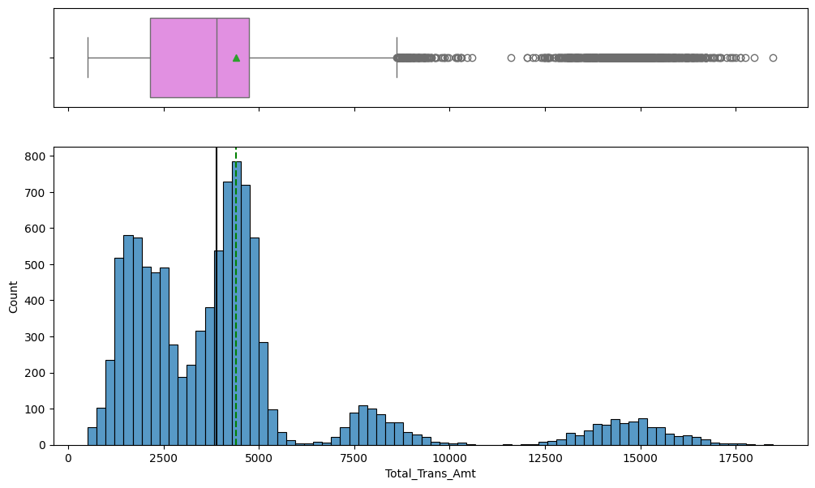

```python
# How is the total transaction amount distributed?

histogram_boxplot(data=df, feature="Total_Trans_Amt")
```

- The total transaction amount is distributed from the majority of the amount being skewed to the right. This means that the transactions do not often cross the 5,000 dollar threshold, they often are below that total amount every year.

### Question 2

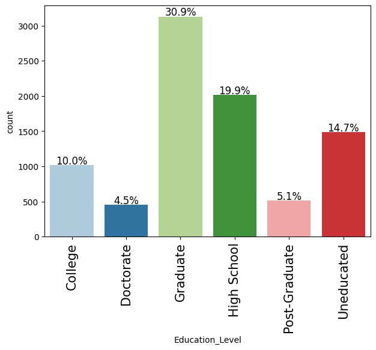

```python
# What is the distribution of the level of education of customers?

labeled_barplot(data=df, feature="Education_Level", perc=True)
```

- The distribution is quite normal, as there appears to be no skewness for this column. However, there are more 'Graduate' & 'High School' education levels compared to the rest of the customers, which possibly aligns with the age group or certain similar backgrounds the customers have with one another.

### Question 3

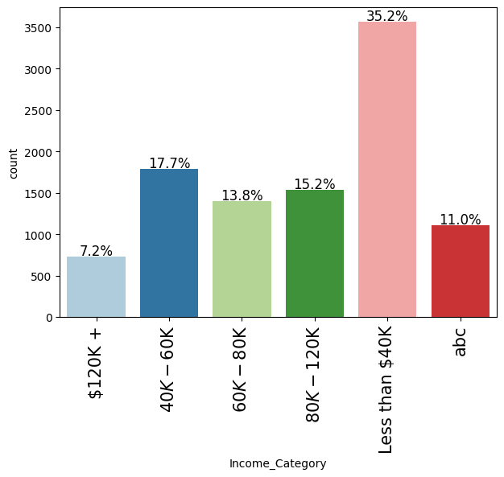

```python
# What is the distribution of the level of income of customers?

labeled_barplot(data=df, feature="Income_Category", perc=True)
```

- The distribution for the level of income of customers is normally distributed for all the categories except customers that have an annual income of less than 40,000 dollars. Similar to the education level, the vast majority of the customers that have an income of 40K or less correlate to the type of area or job they have, or the type of wages in that particular location.

### Question 4

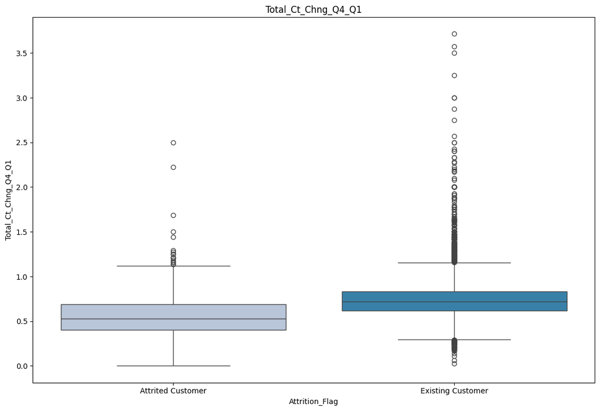

```python
# How does the change in transaction amount between Q4 and Q1 (total_ct_change_Q4_Q1) vary by the customer's account status (Attrition_Flag)?

cols = df[['Total_Ct_Chng_Q4_Q1']].columns.tolist()
plt.figure(figsize=(22,22))

for i, variable in enumerate(cols):
                     plt.subplot(3,2,i+1)
                     sns.boxplot(data=df,x="Attrition_Flag",y=variable,palette="PuBu")
                     plt.tight_layout()
                     plt.title(variable)
plt.show()
```

- The change in transaction amount between quarters 4 and 1 varies for the type of customer status only slightly. For the existing customer status, there are more outliers present as well as a slightly higher amount of ratio compared to those who are attrited. Depending on when the customer has stopped doing business with the company, those who are still existing are always going to have a higher total change in transaction count.

### Question 5

```
Attrition_Flag          Attrited Customer  Existing Customer    All
Months_Inactive_12_mon
All                                  1627               8500  10127
3                                     826               3020   3846
2                                     505               2777   3282
4                                     130                305    435
1                                     100               2133   2233
5                                      32                146    178
6                                      19                105    124
0                                      15                 14     29
------------------------------------------------------------------------------------------------------------------------
```

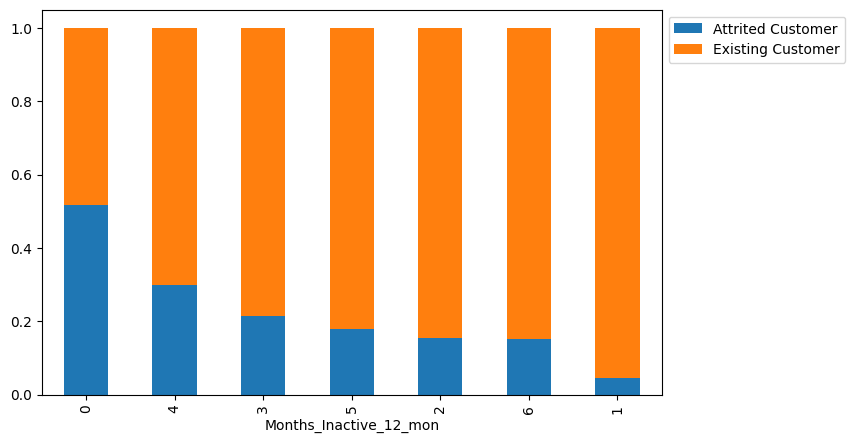

```python
# How does the number of months a customer was inactive in the last 12 months (Months_Inactive_12_mon)
# vary by the customer's account status (Attrition_Flag)?

stacked_barplot(df,"Months_Inactive_12_mon","Attrition_Flag")
```

- As seen in the above-stacked barplot, since there is a vast majority of existing customers compared to those who are attrited, there are always going to be more inactive customers for the ones who still exist. However, in the 0 months portion, more customers were inactive that were attrited than existing, but that was by one.
- Also, there is no correlation on the length of months inactive, as depicted above, the majority of customers who are attracted and existing have been inactive for 3 months.

### Question 6

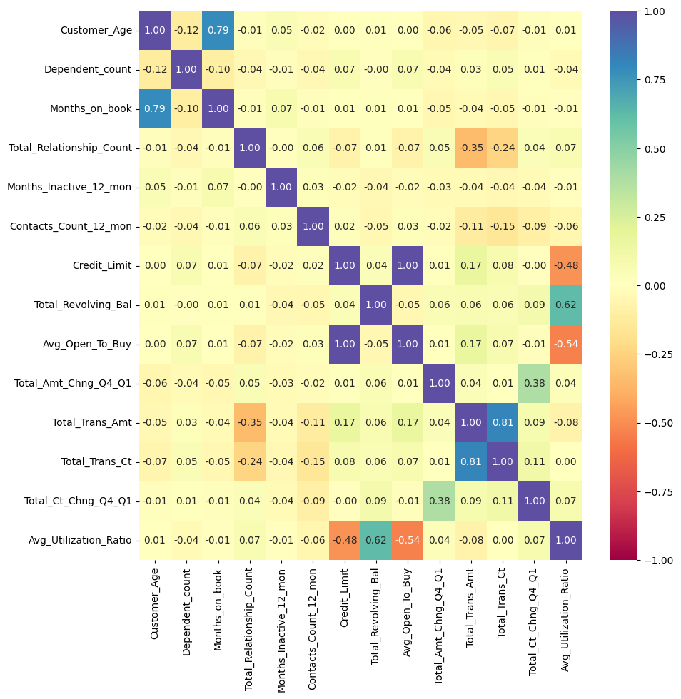

```python
# What are the attributes that have a strong correlation with each other?


# Creating a only number data type heat map, as the categorical columns are not accepted.
numerical_df = df.select_dtypes(include=['number'])

plt.figure(figsize=(10,10))
sns.heatmap(numerical_df.corr(), annot=True, vmin=-1, vmax=1, fmt='.2f', cmap="Spectral")
plt.show()
```

The attributes that have a strong correlation with each other are:

- `Avg_Open_To_Buy` & `Credit_Limit` are perfectly correlated with 1, this will need to be removed during the data splitting phase.
- `Months_on_book` & `Customer_Age` have a strong correlation, this is possible because the older you are the more your relationship with the bank will be.
- `Total_Trans_Amt` & `Total_Trans_Ct` seem to have the highest correlation between all the other numerical data types. This can be because as the total count of transactions increases, the amount also increases with it. This could indicate that the customers chosen in this dataset like to shop frequently and spend more on a yearly average.

#### The below functions need to be defined to carry out the Exploratory Data Analysis.

```python
# function to plot a boxplot and a histogram along the same scale.


def histogram_boxplot(data, feature, figsize=(12, 7), kde=False, bins=None):
    """
    Boxplot and histogram combined

    data: dataframe
    feature: dataframe column
    figsize: size of figure (default (12,7))
    kde: whether to the show density curve (default False)
    bins: number of bins for histogram (default None)
    """
    f2, (ax_box2, ax_hist2) = plt.subplots(
        nrows=2,  # Number of rows of the subplot grid= 2
        sharex=True,  # x-axis will be shared among all subplots
        gridspec_kw={"height_ratios": (0.25, 0.75)},
        figsize=figsize,
    )  # creating the 2 subplots
    sns.boxplot(
        data=data, x=feature, ax=ax_box2, showmeans=True, color="violet"
    )  # boxplot will be created and a triangle will indicate the mean value of the column
    sns.histplot(
        data=data, x=feature, kde=kde, ax=ax_hist2, bins=bins, palette="winter"
    ) if bins else sns.histplot(
        data=data, x=feature, kde=kde, ax=ax_hist2
    )  # For histogram
    ax_hist2.axvline(
        data[feature].mean(), color="green", linestyle="--"
    )  # Add mean to the histogram
    ax_hist2.axvline(
        data[feature].median(), color="black", linestyle="-"
    )  # Add median to the histogram
```

```python
# function to create labeled barplots


def labeled_barplot(data, feature, perc=False, n=None):
    """
    Barplot with percentage at the top

    data: dataframe
    feature: dataframe column
    perc: whether to display percentages instead of count (default is False)
    n: displays the top n category levels (default is None, i.e., display all levels)
    """

    total = len(data[feature])  # length of the column
    count = data[feature].nunique()
    if n is None:
        plt.figure(figsize=(count + 1, 5))
    else:
        plt.figure(figsize=(n + 1, 5))

    plt.xticks(rotation=90, fontsize=15)
    ax = sns.countplot(
        data=data,
        x=feature,
        palette="Paired",
        order=data[feature].value_counts().index[:n].sort_values(),
    )

    for p in ax.patches:
        if perc == True:
            label = "{:.1f}%".format(
                100 * p.get_height() / total
            )  # percentage of each class of the category
        else:
            label = p.get_height()  # count of each level of the category

        x = p.get_x() + p.get_width() / 2  # width of the plot
        y = p.get_height()  # height of the plot

        ax.annotate(
            label,
            (x, y),
            ha="center",
            va="center",
            size=12,
            xytext=(0, 5),
            textcoords="offset points",
        )  # annotate the percentage

    plt.show()  # show the plot
```

```python
# function to plot stacked bar chart

def stacked_barplot(data, predictor, target):
    """
    Print the category counts and plot a stacked bar chart

    data: dataframe
    predictor: independent variable
    target: target variable
    """
    count = data[predictor].nunique()
    sorter = data[target].value_counts().index[-1]
    tab1 = pd.crosstab(data[predictor], data[target], margins=True).sort_values(
        by=sorter, ascending=False
    )
    print(tab1)
    print("-" * 120)
    tab = pd.crosstab(data[predictor], data[target], normalize="index").sort_values(
        by=sorter, ascending=False
    )
    tab.plot(kind="bar", stacked=True, figsize=(count + 1, 5))
    plt.legend(
        loc="lower left", frameon=False,
    )
    plt.legend(loc="upper left", bbox_to_anchor=(1, 1))
    plt.show()
```

```python
### Function to plot distributions

def distribution_plot_wrt_target(data, predictor, target):

    fig, axs = plt.subplots(2, 2, figsize=(12, 10))

    target_uniq = data[target].unique()

    axs[0, 0].set_title("Distribution of target for target=" + str(target_uniq[0]))
    sns.histplot(
        data=data[data[target] == target_uniq[0]],
        x=predictor,
        kde=True,
        ax=axs[0, 0],
        color="teal",
    )

    axs[0, 1].set_title("Distribution of target for target=" + str(target_uniq[1]))
    sns.histplot(
        data=data[data[target] == target_uniq[1]],
        x=predictor,
        kde=True,
        ax=axs[0, 1],
        color="orange",
    )

    axs[1, 0].set_title("Boxplot w.r.t target")
    sns.boxplot(data=data, x=target, y=predictor, ax=axs[1, 0], palette="gist_rainbow")

    axs[1, 1].set_title("Boxplot (without outliers) w.r.t target")
    sns.boxplot(
        data=data,
        x=target,
        y=predictor,
        ax=axs[1, 1],
        showfliers=False,
        palette="gist_rainbow",
    )

    plt.tight_layout()
    plt.show()
```

### Univariate Analysis

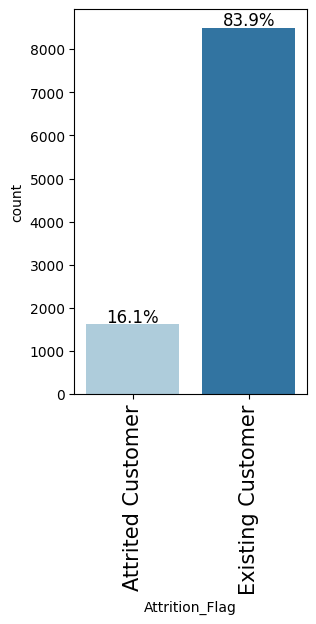

```python
# Observation on Attrition

labeled_barplot(df, "Attrition_Flag", perc=True)
```

- There are significantly more existing customers than attrited, a 68% difference, this is a good statistic to have for a company that wants to decrease the attrited customer percentage even more.

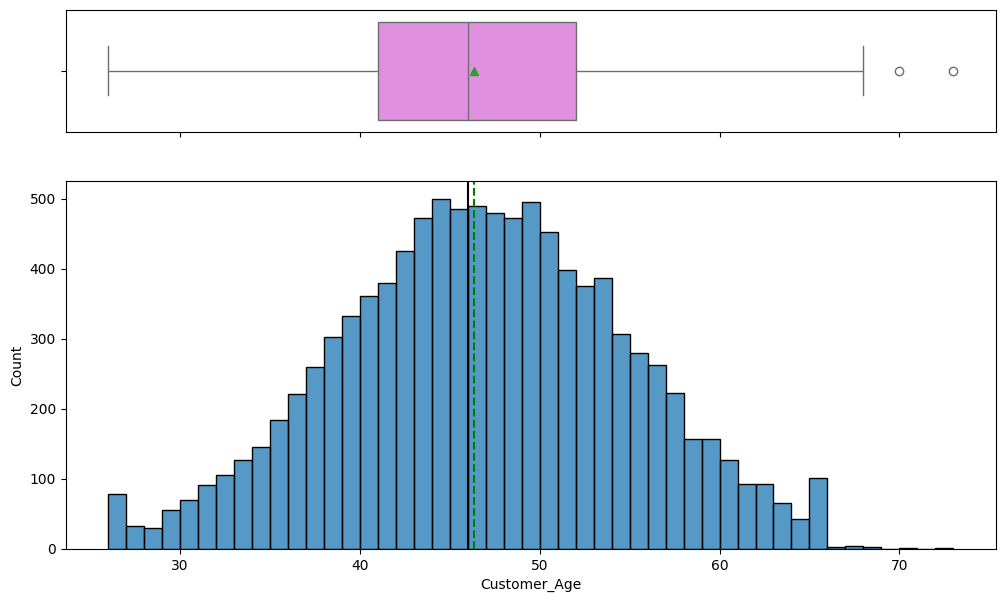

```python
# Observation on Customer_Age

histogram_boxplot(df,'Customer_Age')
```

- The customers age throughout the dataset is almost perfectly normally distributed, with only a few possible outliers being pointed out.

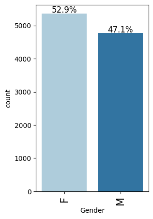

```python
# Observation on Gender

labeled_barplot(df, "Gender", perc=True)
```

- In this dataset, there seems to be some sort of balance between female & males, although there is slighlty a bit more females.

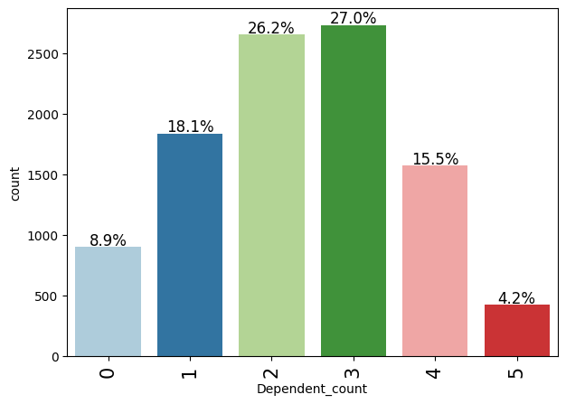

```python
# Observation on Dependent_count

labeled_barplot(df, "Dependent_count", perc=True)
```

- The majority number of dependents being 2 to 3 means that most of the customers have family or children that financially depend on them.

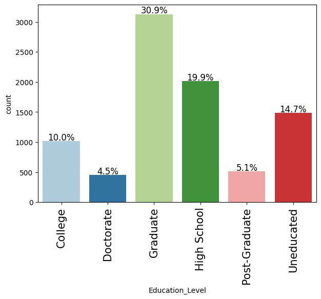

```python
# Observation on Education_Level

labeled_barplot(df, "Education_Level", perc=True)
```

- The majority of customers are either graduates, high school grads, or uneducated. This can portray what and where the customers where picked out from, or their financial background as well.

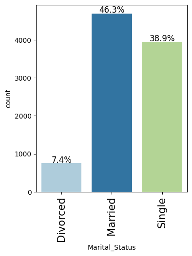

```python
# Observation on Marital_Status

labeled_barplot(df, "Marital_Status", perc=True)
```

- There seems to be a close percentage of customers who are married & single, and a small chunk who are divorced.

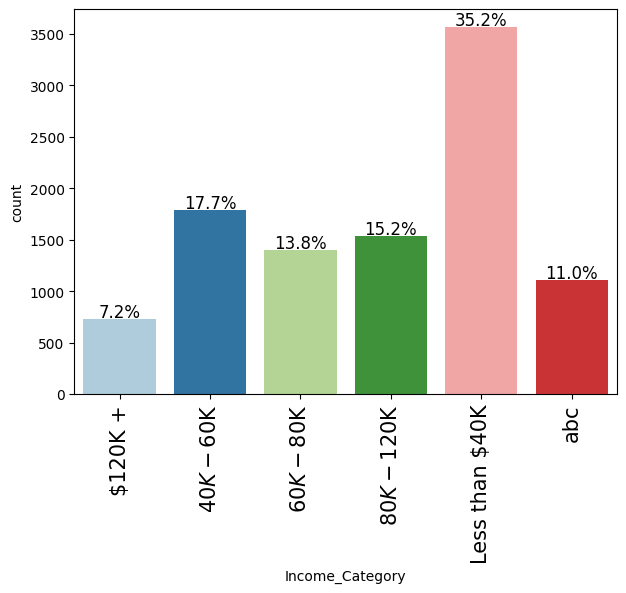

```python
# Observation on Income_Category

labeled_barplot(df, "Income_Category", perc=True)
```

- There is a significant amount of customers who have an annual income of less than 40,000 dollars, this can be correlated to their martial status or even the amount of dependents they have.

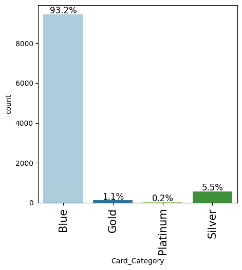

```python
# Observation on Card_Category

labeled_barplot(df, "Card_Category", perc=True)
```

- Almost all customers have a 'Blue' type of card compared to the others.

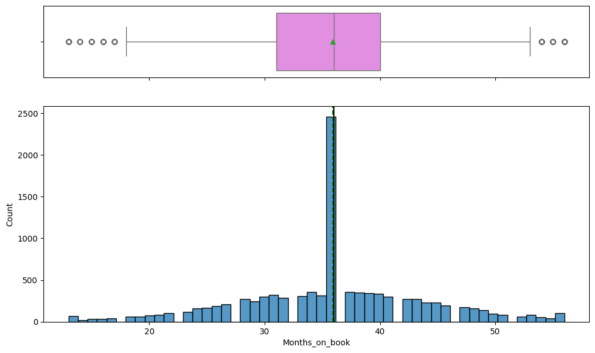

```python
# Observation on Months_on_book

histogram_boxplot(df,'Months_on_book')
```

- The distribtion is normal, however there is a significant amount of customers who have about 35-36 months (3 years) of relationship with the bank.

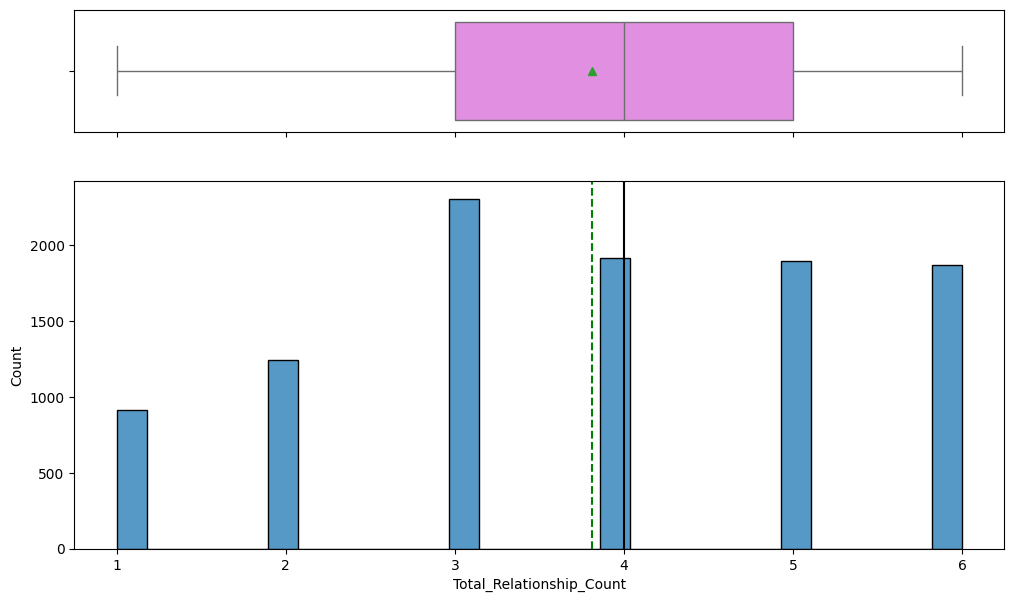

```python
# Observation on Total_Relationship_Count

histogram_boxplot(df,'Total_Relationship_Count')
```

- The total number of products held by the customer seems to be normally distributed with the majority being 3 products.

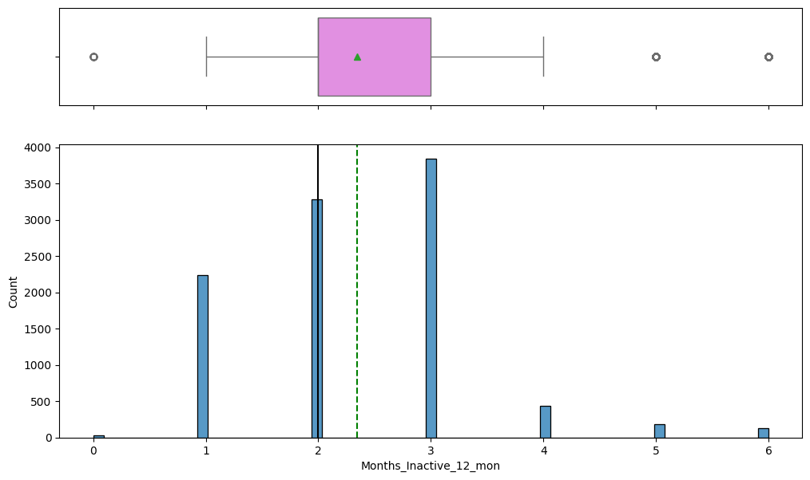

```python
# Observation on Months_Inactive_12_mon

histogram_boxplot(df,'Months_Inactive_12_mon')
```

- The number of months inactive is skewed to the right, with a few outliers past the min an max whiskers. The majority of months is 3 for all customers.

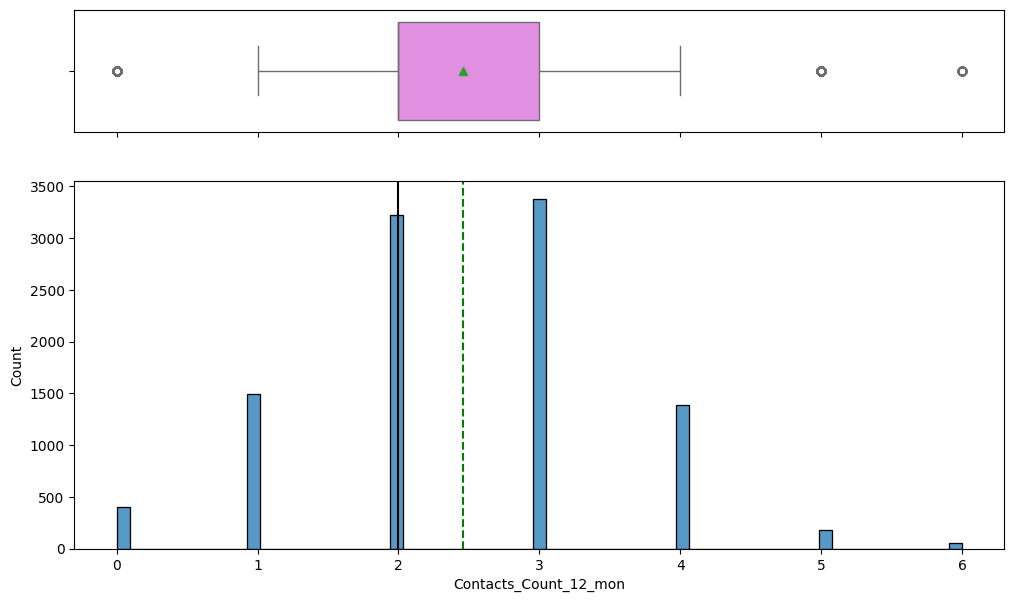

```python
# Observation on Contacts_Count_12_mon

histogram_boxplot(df,'Contacts_Count_12_mon')
```

- The data seems to be normall distributed, with no skewness. Most customers do not really contact the bank more than 2-3 times a year.

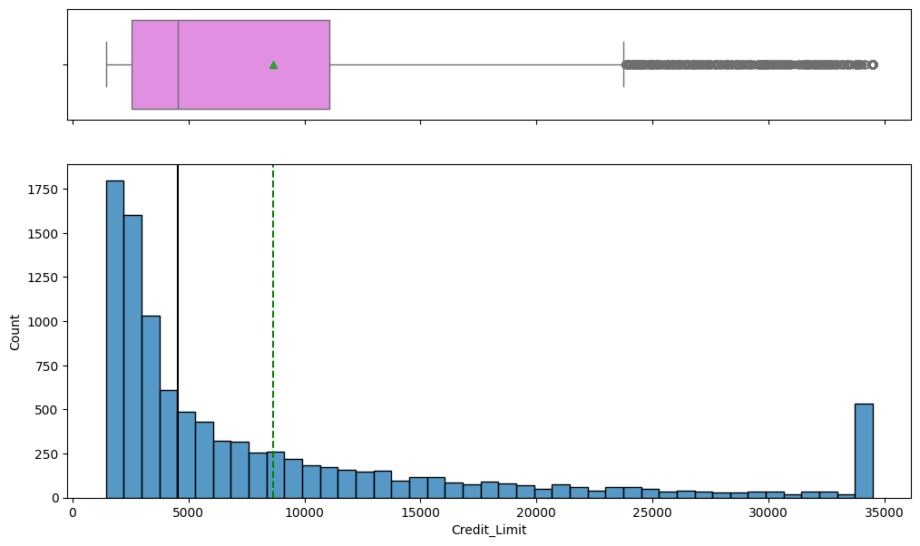

```python
# Observation on Credit_Limit

histogram_boxplot(df,'Credit_Limit')
```

- The data is heavily skewed to the right, with the majority of the customers having a credit limit of less than 5,000 dollars. There are also a lot of outliers that are high valued.

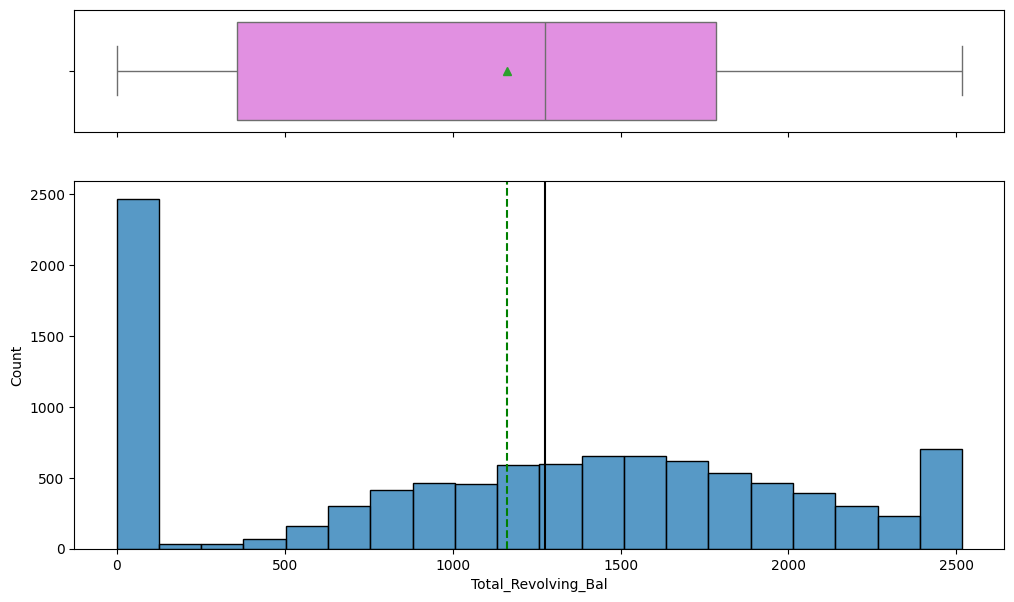

```python
# Observation on Total_Revolving_Bal

histogram_boxplot(df,'Total_Revolving_Bal')
```

- The data is distributed normally, with a significant amount of customers having no money being carreid over to the next month.

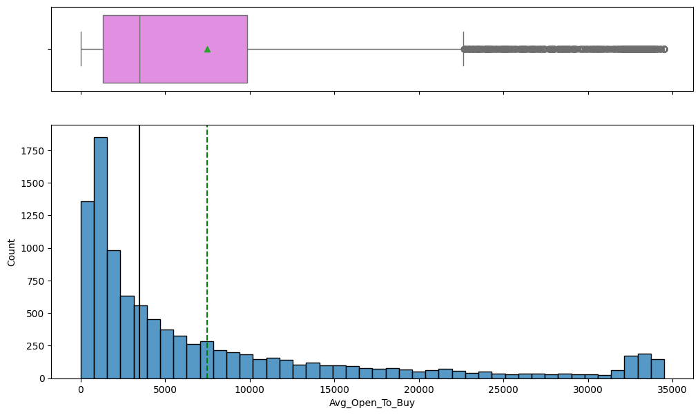

```python
# Observation on Avg_Open_To_Buy

histogram_boxplot(df,'Avg_Open_To_Buy')
```

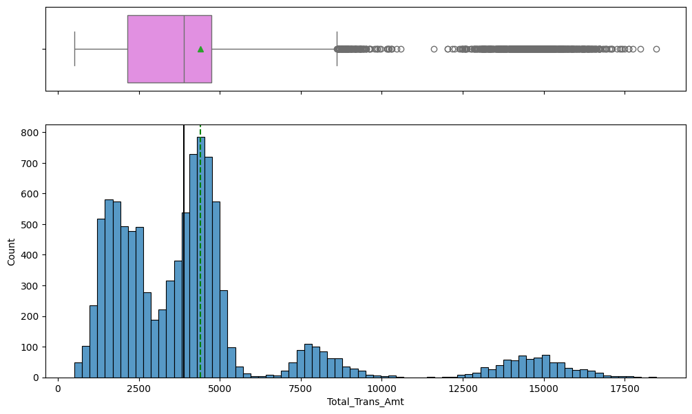

```python
# Observation on Total_Trans_Amt

histogram_boxplot(df,'Total_Trans_Amt')
```

- The total transaction amount is somewhat skewed to the right, most customers spend no more than 5,000 dollars a year which is pretty low. However, for most customers average of around 40,0000 dollars, it isn't that surprising.

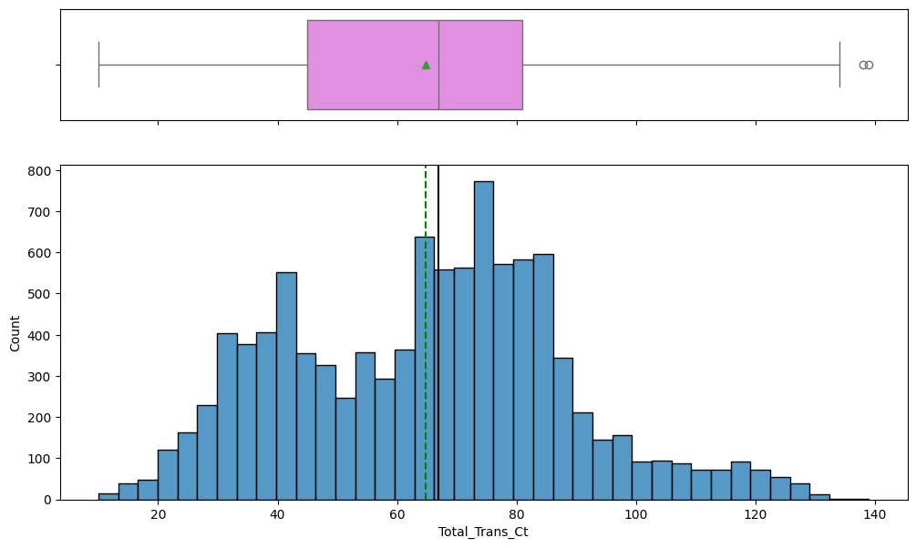

```python
# Observation on Total_Trans_Ct

histogram_boxplot(df,'Total_Trans_Ct')
```

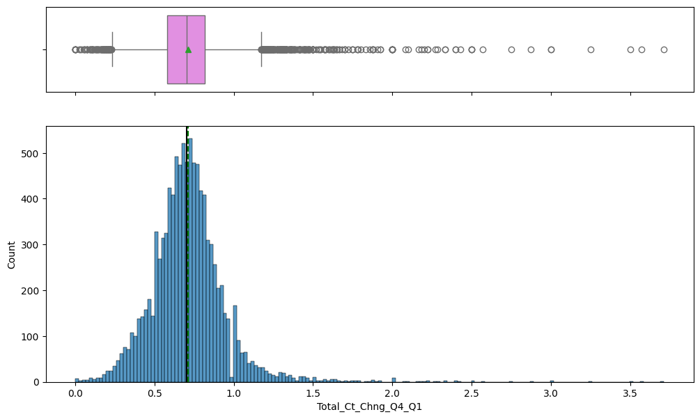

```python
# Observation on Total_Ct_Chng_Q4_Q1

histogram_boxplot(df,'Total_Ct_Chng_Q4_Q1')
```

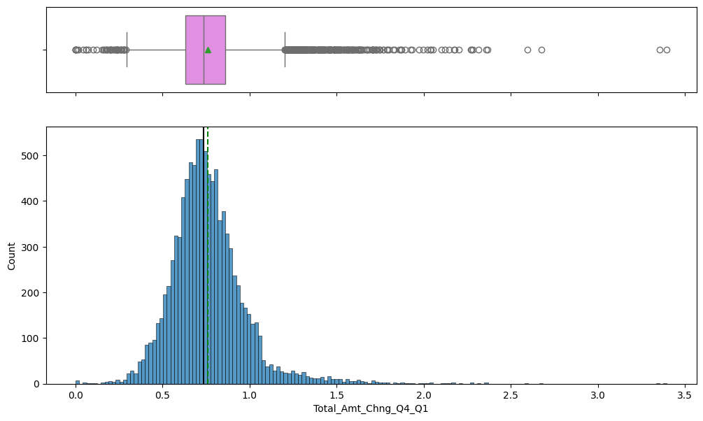

```python
# Observation on Total_Amt_Chng_Q4_Q1

histogram_boxplot(df,'Total_Amt_Chng_Q4_Q1')
```

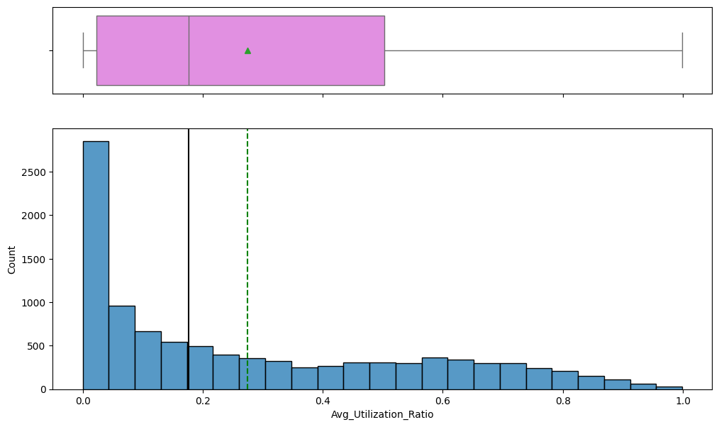

```python
# Observation on Avg_Utilization_Ratio

histogram_boxplot(df,'Avg_Utilization_Ratio')
```

### Bivariate Analysis

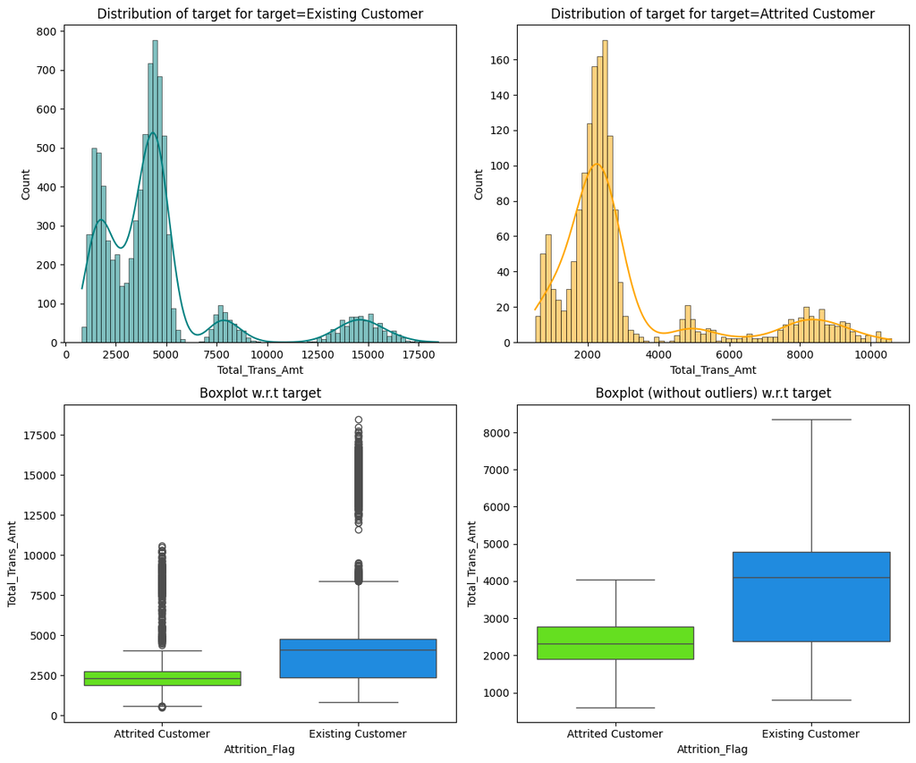

```python
# Relationship Between Total_Trans_Amt & Attrition_Flag

distribution_plot_wrt_target(df, "Total_Trans_Amt", "Attrition_Flag")
```

- From the above distribution plot, it seems like the existing customers have a higher total transaction amount than those who are attrited. This can provide insights into the relationship between the customers spending behavior and their retention.
- The data also is heavily skewed to the right.

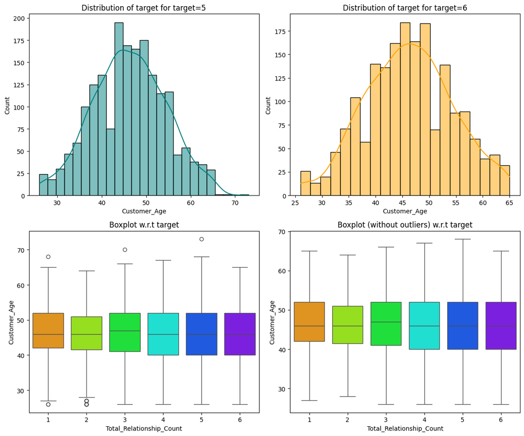

```python
# Relationship between Customer_Avg & Total_Relationship_Count

distribution_plot_wrt_target(df, "Customer_Age", "Total_Relationship_Count")
```

- The data is normally distributed, therefore there does not seem to be any correlation on whether younger or older customers have more or fewer products they hold with the bank.

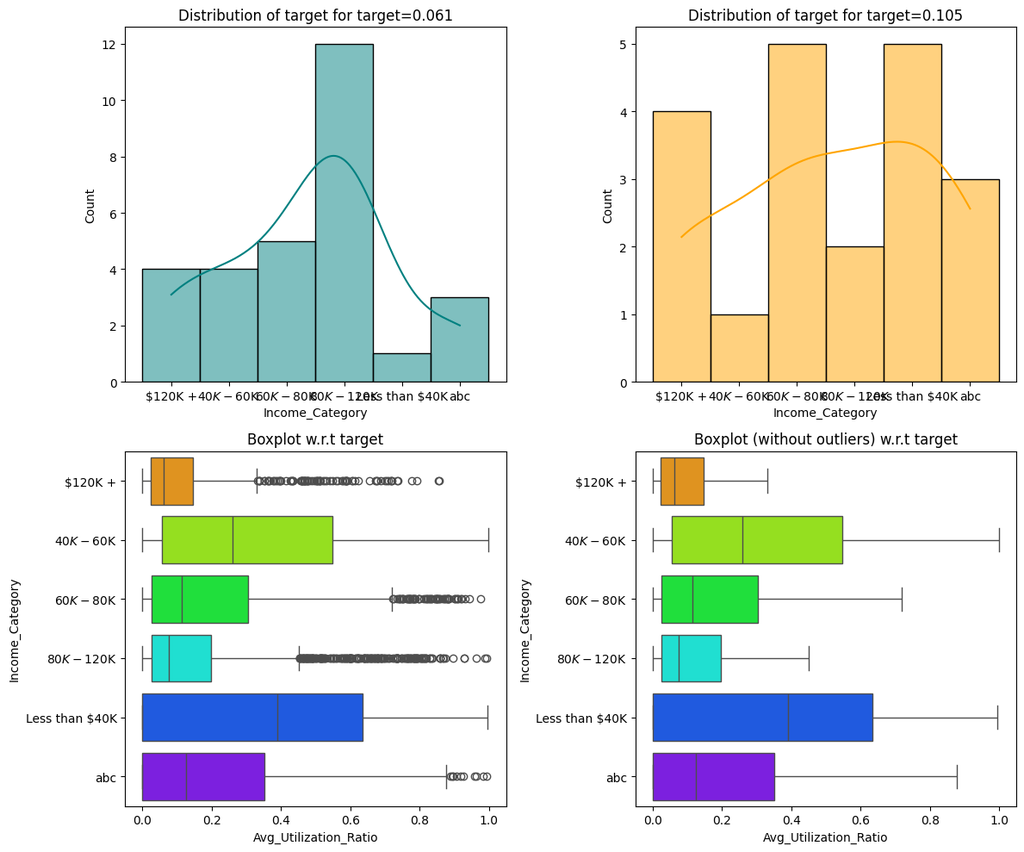

```python
# Relationship between Income_Category & Avg_Utilizaiton_Ratio

distribution_plot_wrt_target(df, "Income_Category", "Avg_Utilization_Ratio")
```

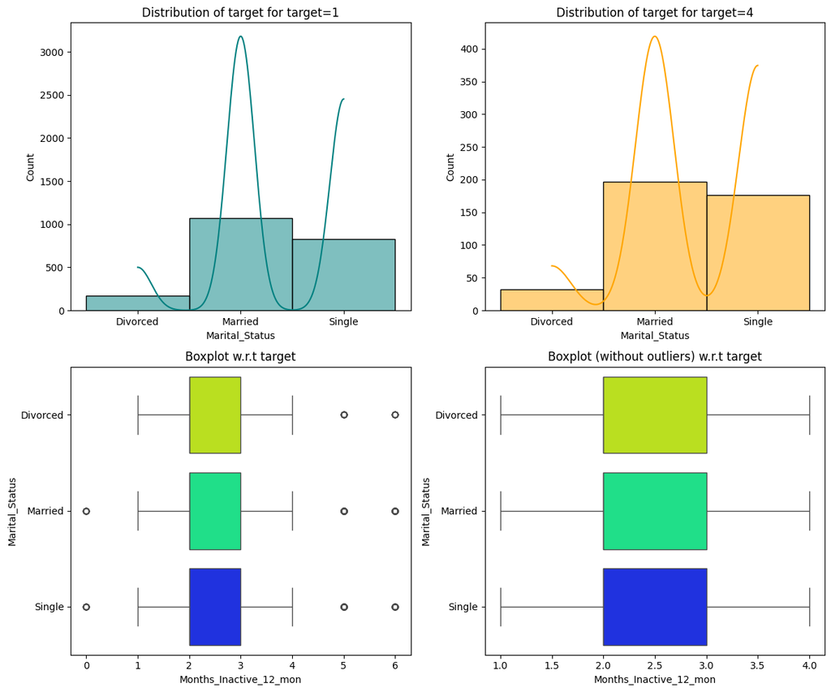

```python
# Relationship between Martial_Status & Months_Inactive_12_mon

distribution_plot_wrt_target(df, "Marital_Status", "Months_Inactive_12_mon")
```

- There does not seem to be any impact on customer engagement or inactivity as the data is normally distributed.

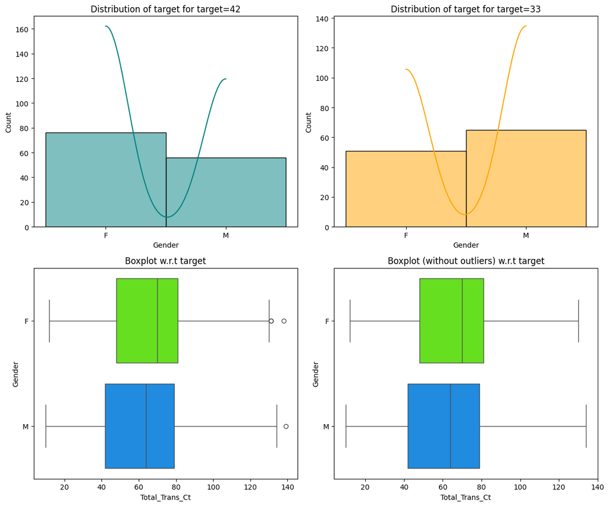

```python
# Relationship between Gender vs. Total_Trans_Ct

distribution_plot_wrt_target(df, "Gender", "Total_Trans_Ct")
```

- There does not seem to be any significant differences in how often a male or female customer makes their transactions as the statistics are normally distributed.

## Data Pre-processing

### Outlier Detection

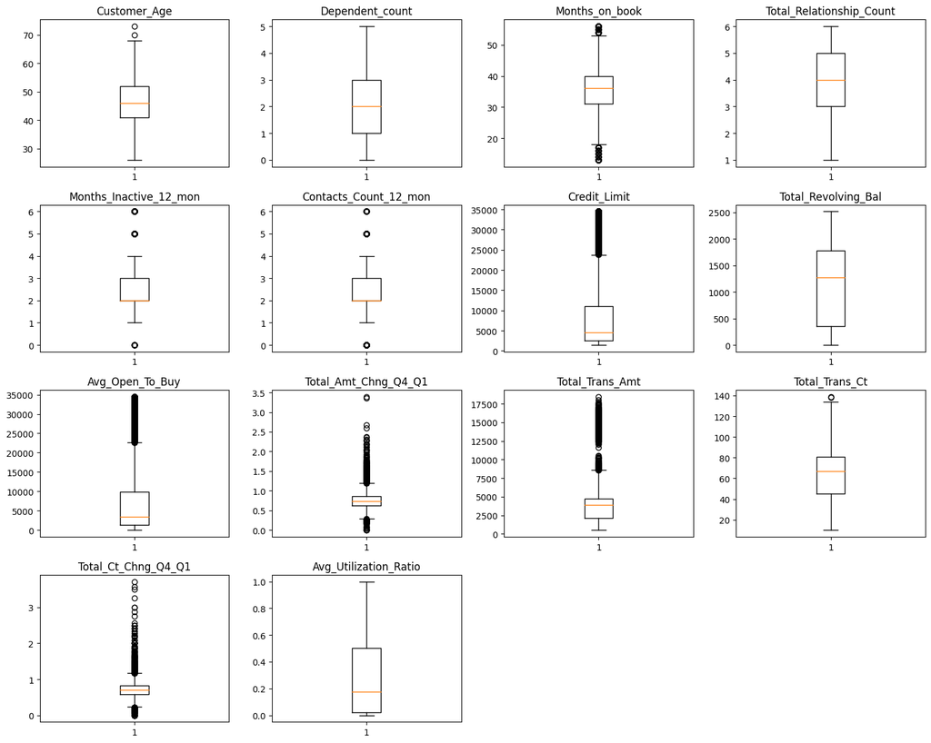

```python
# outlier detection using boxplots
numeric_columns = df.select_dtypes(include=np.number).columns.tolist()

plt.figure(figsize=(15, 12))

for i, variable in enumerate(numeric_columns):
    plt.subplot(4, 4, i + 1)
    plt.boxplot(df[variable], whis=1.5)
    plt.tight_layout()
    plt.title(variable)

plt.show()
```

- There seem to be outliers in multiple columns
  - The `Months_on_book`columns outliers do not need to be treated
  - The `Credit_Limit` column outliers seem to be normal as there can be some customers who exceed their credit limit from the average.
  - The `Avg_Open_To_Buy` columns outliers do not need to be treated.
  - The rest of the columns that contain outliers do not need to be treated as there can be instances of customers having or not having the same range of income or balance in their cards.

## Missing value imputation

#### Education_Level

```python
# Count the percentage of missing values (if any) in each column

pd.DataFrame({'Count':df.isnull().sum()[df.isnull().sum()>0],'Percentage':(df.isnull().sum()[df.isnull().sum()>0]/df.shape[0])*100})
```

|  | Count | Percentage |
| --- | --- | --- |
| Education_Level | 1519 | 14.999506 |
| Marital_Status | 749 | 7.396070 |

- As seen above, there are two columns with missing data, the 'Education_Level' column has 15% missing data, whilst the Martial_Status has 7%.

```python
# Checking the missing values further
df.Education_Level.value_counts(normalize=True, dropna=False)
```

| Education_Level | proportion |
| --- | --- |
| Graduate | 0.308877 |
| High School | 0.198776 |
| NaN | 0.149995 |
| Uneducated | 0.146835 |
| College | 0.100030 |
| Post-Graduate | 0.050953 |
| Doctorate | 0.044534 |

**dtype:** float64

The categories contain a mixed set of proportions, the mode is the 'Graduate'.

```python
df.loc[df['Education_Level'].isnull()==True]
```

|  | Attrition_Flag | Customer_Age | Gender | Dependent_count | Education_Level | Marital_Status | Income_Category | Card_Category | Months_on_book | Total_Relationship_Count | Months_Inactive_12_mon | Contacts_Count_12_mon | Credit_Limit | Total_Revolving_Bal | Avg_Open_To_Buy | Total_Amt_Chng_Q4_Q1 | Total_Trans_Amt | Total_Trans_Ct | Total_Ct_Chng_Q4_Q1 | Avg_Utilization_Ratio |
| --- | --- | --- | --- | --- | --- | --- | --- | --- | --- | --- | --- | --- | --- | --- | --- | --- | --- | --- | --- | --- |
| 6 | Existing Customer | 51 | M | 4 | NaN | Married | $120K + | Gold | 46 | 6 | 1 | 3 | 34516.0 | 2264 | 32252.0 | 1.975 | 1330 | 31 | 0.722 | 0.066 |
| 11 | Existing Customer | 65 | M | 1 | NaN | Married | $40K - $60K | Blue | 54 | 6 | 2 | 3 | 9095.0 | 1587 | 7508.0 | 1.433 | 1314 | 26 | 1.364 | 0.174 |
| 15 | Existing Customer | 44 | M | 4 | NaN | NaN | $80K - $120K | Blue | 37 | 5 | 1 | 2 | 4234.0 | 972 | 3262.0 | 1.707 | 1348 | 27 | 1.700 | 0.230 |
| 17 | Existing Customer | 41 | M | 3 | NaN | Married | $80K - $120K | Blue | 34 | 4 | 4 | 1 | 13535.0 | 1291 | 12244.0 | 0.653 | 1028 | 21 | 1.625 | 0.095 |
| 23 | Existing Customer | 47 | F | 4 | NaN | Single | Less than $40K | Blue | 36 | 3 | 3 | 2 | 2492.0 | 1560 | 932.0 | 0.573 | 1126 | 23 | 0.353 | 0.626 |
| ... | ... | ... | ... | ... | ... | ... | ... | ... | ... | ... | ... | ... | ... | ... | ... | ... | ... | ... | ... | ... |
| 10090 | Existing Customer | 36 | F | 3 | NaN | Married | $40K - $60K | Blue | 22 | 5 | 3 | 3 | 12958.0 | 2273 | 10685.0 | 0.608 | 15681 | 96 | 0.627 | 0.175 |
| 10094 | Existing Customer | 59 | M | 1 | NaN | Single | $60K - $80K | Blue | 48 | 3 | 1 | 2 | 7288.0 | 0 | 7288.0 | 0.640 | 14873 | 120 | 0.714 | 0.000 |
| 10095 | Existing Customer | 46 | M | 3 | NaN | Married | $80K - $120K | Blue | 33 | 4 | 1 | 3 | 34516.0 | 1099 | 33417.0 | 0.816 | 15490 | 110 | 0.618 | 0.032 |
| 10118 | Attrited Customer | 50 | M | 1 | NaN | NaN | $80K - $120K | Blue | 36 | 6 | 3 | 4 | 9959.0 | 952 | 9007.0 | 0.825 | 10310 | 63 | 1.100 | 0.096 |
| 10123 | Attrited Customer | 41 | M | 2 | NaN | Divorced | $40K - $60K | Blue | 25 | 4 | 2 | 3 | 4277.0 | 2186 | 2091.0 | 0.804 | 8764 | 69 | 0.683 | 0.511 |

1519 rows × 20 columns

- It seems like there is no correlation or other columns that correlate on why the values are missing from the column, this could be due to the vast amount of missing data.

Therefore we can replace all the 'NaN' values with 'Unknown' in the Education_Level column

```python
# Check if 'Unknown' is already a category
if 'Unknown' not in df['Education_Level'].cat.categories:
    df['Education_Level'] = df['Education_Level'].cat.add_categories('Unknown')

# Now you can fill NaN values with 'Unknown'
df['Education_Level'].fillna('Unknown', inplace=True)
```

```python
df['Education_Level'].unique()
```

```
['High School', 'Graduate', 'Uneducated', 'Unknown', 'College', 'Post-Graduate', 'Doctorate']
Categories (7, object): ['College', 'Doctorate', 'Graduate', 'High School', 'Post-Graduate',
                         'Uneducated', 'Unknown']
```

There is now an Unkown category to replace all the NaN values

```python
df.isnull().sum()
```

|  | 0 |
| --- | --- |
| Attrition_Flag | 0 |
| Customer_Age | 0 |
| Gender | 0 |
| Dependent_count | 0 |
| Education_Level | 0 |
| Marital_Status | 749 |
| Income_Category | 0 |
| Card_Category | 0 |
| Months_on_book | 0 |
| Total_Relationship_Count | 0 |
| Months_Inactive_12_mon | 0 |
| Contacts_Count_12_mon | 0 |
| Credit_Limit | 0 |
| Total_Revolving_Bal | 0 |
| Avg_Open_To_Buy | 0 |
| Total_Amt_Chng_Q4_Q1 | 0 |
| Total_Trans_Amt | 0 |
| Total_Trans_Ct | 0 |
| Total_Ct_Chng_Q4_Q1 | 0 |
| Avg_Utilization_Ratio | 0 |

**dtype:** int64

The Education_Level category missing values are now treated.

#### Marital_Status

```python
df.isnull().sum()
```

|  | 0 |
| --- | --- |
| Attrition_Flag | 0 |
| Customer_Age | 0 |
| Gender | 0 |
| Dependent_count | 0 |
| Education_Level | 0 |
| Marital_Status | 749 |
| Income_Category | 0 |
| Card_Category | 0 |
| Months_on_book | 0 |
| Total_Relationship_Count | 0 |
| Months_Inactive_12_mon | 0 |
| Contacts_Count_12_mon | 0 |
| Credit_Limit | 0 |
| Total_Revolving_Bal | 0 |
| Avg_Open_To_Buy | 0 |
| Total_Amt_Chng_Q4_Q1 | 0 |
| Total_Trans_Amt | 0 |
| Total_Trans_Ct | 0 |
| Total_Ct_Chng_Q4_Q1 | 0 |
| Avg_Utilization_Ratio | 0 |

**dtype:** int64

```python
# Checking the missing values further
df.Marital_Status.value_counts(normalize=True, dropna=False)
```

| Marital_Status | proportion |
| --- | --- |
| Married | 0.462822 |
| Single | 0.389355 |
| NaN | 0.073961 |
| Divorced | 0.073862 |

**dtype:** float64

- There does not seem to be much of a proportion of the amount of missing data compared to the other categories in the column, although it still needs to be treated.

```python
# See if there is any correlation for the missing values

df.loc[df['Marital_Status'].isnull()==True]
```

|  | Attrition_Flag | Customer_Age | Gender | Dependent_count | Education_Level | Marital_Status | Income_Category | Card_Category | Months_on_book | Total_Relationship_Count | Months_Inactive_12_mon | Contacts_Count_12_mon | Credit_Limit | Total_Revolving_Bal | Avg_Open_To_Buy | Total_Amt_Chng_Q4_Q1 | Total_Trans_Amt | Total_Trans_Ct | Total_Ct_Chng_Q4_Q1 | Avg_Utilization_Ratio |
| --- | --- | --- | --- | --- | --- | --- | --- | --- | --- | --- | --- | --- | --- | --- | --- | --- | --- | --- | --- | --- |
| 3 | Existing Customer | 40 | F | 4 | High School | NaN | Less than $40K | Blue | 34 | 3 | 4 | 1 | 3313.0 | 2517 | 796.0 | 1.405 | 1171 | 20 | 2.333 | 0.760 |
| 7 | Existing Customer | 32 | M | 0 | High School | NaN | $60K - $80K | Silver | 27 | 2 | 2 | 2 | 29081.0 | 1396 | 27685.0 | 2.204 | 1538 | 36 | 0.714 | 0.048 |
| 10 | Existing Customer | 42 | M | 5 | Uneducated | NaN | $120K + | Blue | 31 | 5 | 3 | 2 | 6748.0 | 1467 | 5281.0 | 0.831 | 1201 | 42 | 0.680 | 0.217 |
| 13 | Existing Customer | 35 | M | 3 | Graduate | NaN | $60K - $80K | Blue | 30 | 5 | 1 | 3 | 8547.0 | 1666 | 6881.0 | 1.163 | 1311 | 33 | 2.000 | 0.195 |
| 15 | Existing Customer | 44 | M | 4 | Unknown | NaN | $80K - $120K | Blue | 37 | 5 | 1 | 2 | 4234.0 | 972 | 3262.0 | 1.707 | 1348 | 27 | 1.700 | 0.230 |
| ... | ... | ... | ... | ... | ... | ... | ... | ... | ... | ... | ... | ... | ... | ... | ... | ... | ... | ... | ... | ... |
| 10070 | Existing Customer | 47 | M | 3 | High School | NaN | $80K - $120K | Silver | 40 | 5 | 3 | 2 | 34516.0 | 1371 | 33145.0 | 0.691 | 15930 | 123 | 0.836 | 0.040 |
| 10100 | Existing Customer | 39 | M | 2 | Graduate | NaN | $60K - $80K | Silver | 36 | 4 | 2 | 2 | 29808.0 | 0 | 29808.0 | 0.669 | 16098 | 128 | 0.684 | 0.000 |
| 10101 | Existing Customer | 42 | M | 2 | Graduate | NaN | $40K - $60K | Blue | 30 | 3 | 2 | 5 | 3735.0 | 1723 | 2012.0 | 0.595 | 14501 | 92 | 0.840 | 0.461 |
| 10118 | Attrited Customer | 50 | M | 1 | Unknown | NaN | $80K - $120K | Blue | 36 | 6 | 3 | 4 | 9959.0 | 952 | 9007.0 | 0.825 | 10310 | 63 | 1.100 | 0.096 |
| 10125 | Attrited Customer | 30 | M | 2 | Graduate | NaN | $40K - $60K | Blue | 36 | 4 | 3 | 3 | 5281.0 | 0 | 5281.0 | 0.535 | 8395 | 62 | 0.722 | 0.000 |

749 rows × 20 columns

```python
# Replacing NaN with Unknown for the Marital_Status

# Check if 'Unknown' is already a category, and only add it if it's not.
if 'Unknown' not in df['Marital_Status'].cat.categories:
    df['Marital_Status'] = df['Marital_Status'].cat.add_categories('Unknown')

# Now fill the missing values
df['Marital_Status'].fillna('Unknown', inplace=True)
```

```python
df['Marital_Status'].unique()
```

```
['Married', 'Single', 'Unknown', 'Divorced']
Categories (4, object): ['Divorced', 'Married', 'Single', 'Unknown']
```

- Unknown category within the column has been added to transfer the NaN values

```python
df.isnull().sum()
```

|  | 0 |
| --- | --- |
| Attrition_Flag | 0 |
| Customer_Age | 0 |
| Gender | 0 |
| Dependent_count | 0 |
| Education_Level | 0 |
| Marital_Status | 0 |
| Income_Category | 0 |
| Card_Category | 0 |
| Months_on_book | 0 |
| Total_Relationship_Count | 0 |
| Months_Inactive_12_mon | 0 |
| Contacts_Count_12_mon | 0 |
| Credit_Limit | 0 |
| Total_Revolving_Bal | 0 |
| Avg_Open_To_Buy | 0 |
| Total_Amt_Chng_Q4_Q1 | 0 |
| Total_Trans_Amt | 0 |
| Total_Trans_Ct | 0 |
| Total_Ct_Chng_Q4_Q1 | 0 |
| Avg_Utilization_Ratio | 0 |

**dtype:** int64

There is now no missing values to be treated within the dataset.

```python
df.head()
```

|  | Attrition_Flag | Customer_Age | Gender | Dependent_count | Education_Level | Marital_Status | Income_Category | Card_Category | Months_on_book | Total_Relationship_Count | Months_Inactive_12_mon | Contacts_Count_12_mon | Credit_Limit | Total_Revolving_Bal | Avg_Open_To_Buy | Total_Amt_Chng_Q4_Q1 | Total_Trans_Amt | Total_Trans_Ct | Total_Ct_Chng_Q4_Q1 | Avg_Utilization_Ratio |
| --- | --- | --- | --- | --- | --- | --- | --- | --- | --- | --- | --- | --- | --- | --- | --- | --- | --- | --- | --- | --- |
| 0 | Existing Customer | 45 | M | 3 | High School | Married | $60K - $80K | Blue | 39 | 5 | 1 | 3 | 12691.0 | 777 | 11914.0 | 1.335 | 1144 | 42 | 1.625 | 0.061 |
| 1 | Existing Customer | 49 | F | 5 | Graduate | Single | Less than $40K | Blue | 44 | 6 | 1 | 2 | 8256.0 | 864 | 7392.0 | 1.541 | 1291 | 33 | 3.714 | 0.105 |
| 2 | Existing Customer | 51 | M | 3 | Graduate | Married | $80K - $120K | Blue | 36 | 4 | 1 | 0 | 3418.0 | 0 | 3418.0 | 2.594 | 1887 | 20 | 2.333 | 0.000 |
| 3 | Existing Customer | 40 | F | 4 | High School | Unknown | Less than $40K | Blue | 34 | 3 | 4 | 1 | 3313.0 | 2517 | 796.0 | 1.405 | 1171 | 20 | 2.333 | 0.760 |
| 4 | Existing Customer | 40 | M | 3 | Uneducated | Married | $60K - $80K | Blue | 21 | 5 | 1 | 0 | 4716.0 | 0 | 4716.0 | 2.175 | 816 | 28 | 2.500 | 0.000 |

## Model Building

#### Data Preparation for model building

```python
df.head()
```

|  | Attrition_Flag | Customer_Age | Gender | Dependent_count | Education_Level | Marital_Status | Income_Category | Card_Category | Months_on_book | Total_Relationship_Count | Months_Inactive_12_mon | Contacts_Count_12_mon | Credit_Limit | Total_Revolving_Bal | Avg_Open_To_Buy | Total_Amt_Chng_Q4_Q1 | Total_Trans_Amt | Total_Trans_Ct | Total_Ct_Chng_Q4_Q1 | Avg_Utilization_Ratio |
| --- | --- | --- | --- | --- | --- | --- | --- | --- | --- | --- | --- | --- | --- | --- | --- | --- | --- | --- | --- | --- |
| 0 | Existing Customer | 45 | M | 3 | High School | Married | $60K - $80K | Blue | 39 | 5 | 1 | 3 | 12691.0 | 777 | 11914.0 | 1.335 | 1144 | 42 | 1.625 | 0.061 |
| 1 | Existing Customer | 49 | F | 5 | Graduate | Single | Less than $40K | Blue | 44 | 6 | 1 | 2 | 8256.0 | 864 | 7392.0 | 1.541 | 1291 | 33 | 3.714 | 0.105 |
| 2 | Existing Customer | 51 | M | 3 | Graduate | Married | $80K - $120K | Blue | 36 | 4 | 1 | 0 | 3418.0 | 0 | 3418.0 | 2.594 | 1887 | 20 | 2.333 | 0.000 |
| 3 | Existing Customer | 40 | F | 4 | High School | Unknown | Less than $40K | Blue | 34 | 3 | 4 | 1 | 3313.0 | 2517 | 796.0 | 1.405 | 1171 | 20 | 2.333 | 0.760 |
| 4 | Existing Customer | 40 | M | 3 | Uneducated | Married | $60K - $80K | Blue | 21 | 5 | 1 | 0 | 4716.0 | 0 | 4716.0 | 2.175 | 816 | 28 | 2.500 | 0.000 |

```python
# Creating dummy variables throughout the data set:

df = pd.get_dummies(df, drop_first=True)
```

```python
# Make the dummy variables 1s and 0s instead of true and false

df = df.replace({False: 0, True: 1})
```

```python
df.head()
```

|  | Customer_Age | Dependent_count | Months_on_book | Total_Relationship_Count | Months_Inactive_12_mon | Contacts_Count_12_mon | Credit_Limit | Total_Revolving_Bal | Avg_Open_To_Buy | Total_Amt_Chng_Q4_Q1 | ... | Marital_Status_Single | Marital_Status_Unknown | Income_Category_$40K - $60K | Income_Category_$60K - $80K | Income_Category_$80K - $120K | Income_Category_Less than $40K | Income_Category_abc | Card_Category_Gold | Card_Category_Platinum | Card_Category_Silver |
| --- | --- | --- | --- | --- | --- | --- | --- | --- | --- | --- | --- | --- | --- | --- | --- | --- | --- | --- | --- | --- | --- |
| 0 | 45 | 3 | 39 | 5 | 1 | 3 | 12691.0 | 777 | 11914.0 | 1.335 | ... | 0 | 0 | 0 | 1 | 0 | 0 | 0 | 0 | 0 | 0 |
| 1 | 49 | 5 | 44 | 6 | 1 | 2 | 8256.0 | 864 | 7392.0 | 1.541 | ... | 1 | 0 | 0 | 0 | 0 | 1 | 0 | 0 | 0 | 0 |
| 2 | 51 | 3 | 36 | 4 | 1 | 0 | 3418.0 | 0 | 3418.0 | 2.594 | ... | 0 | 0 | 0 | 0 | 1 | 0 | 0 | 0 | 0 | 0 |
| 3 | 40 | 4 | 34 | 3 | 4 | 1 | 3313.0 | 2517 | 796.0 | 1.405 | ... | 0 | 1 | 0 | 0 | 0 | 1 | 0 | 0 | 0 | 0 |
| 4 | 40 | 3 | 21 | 5 | 1 | 0 | 4716.0 | 0 | 4716.0 | 2.175 | ... | 0 | 0 | 0 | 1 | 0 | 0 | 0 | 0 | 0 | 0 |

5 rows × 33 columns

```python
# Removing 'Income_Category_abc' column

df = df.drop(columns=['Income_Category_abc'])
```

- Now all the necessary variables are one-hot encoded, the data is now ready to be split.

```python
df.info()
```

```
<class 'pandas.core.frame.DataFrame'>
RangeIndex: 10127 entries, 0 to 10126
Data columns (total 32 columns):
 #   Column                            Non-Null Count  Dtype
---  ------                            --------------  -----
 0   Customer_Age                      10127 non-null  int64
 1   Dependent_count                   10127 non-null  int64
 2   Months_on_book                    10127 non-null  int64
 3   Total_Relationship_Count          10127 non-null  int64
 4   Months_Inactive_12_mon            10127 non-null  int64
 5   Contacts_Count_12_mon             10127 non-null  int64
 6   Credit_Limit                      10127 non-null  float64
 7   Total_Revolving_Bal               10127 non-null  int64
 8   Avg_Open_To_Buy                   10127 non-null  float64
 9   Total_Amt_Chng_Q4_Q1              10127 non-null  float64
```

[output cut: 24 more lines]

```python
from sklearn.model_selection import train_test_split

# Assuming `df` is your DataFrame and 'Attrition_Flag' is the target column
X = df.drop(columns=['Attrition_Flag_Existing Customer', 'Credit_Limit'])  # Features
y = df['Attrition_Flag_Existing Customer']  # Target

# Step 1: Split the data into training + validation and test sets
X_train_val, X_test, y_train_val, y_test = train_test_split(X, y, test_size=0.2, random_state=42, stratify=y)

# Step 2: Split the training + validation set into training and validation sets
X_train, X_val, y_train, y_val = train_test_split(X_train_val, y_train_val, test_size=0.25, random_state=42, stratify=y_train_val)
```

```python
y.value_counts(1)
```

| Attrition_Flag_Existing Customer | proportion |
| --- | --- |
| 1 | 0.83934 |
| 0 | 0.16066 |

**dtype:** float64

```python
y_test.value_counts(1)
```

| Attrition_Flag_Existing Customer | proportion |
| --- | --- |
| 1 | 0.839585 |
| 0 | 0.160415 |

**dtype:** float64

### Model evaluation criterion

**Let's define a function to output different metrics (including recall) on the train and test set and a function to show confusion matrix so that we do not have to use the same code repetitively while evaluating models.**

```python
# defining a function to compute different metrics to check performance of a classification model built using sklearn
def model_performance_classification_sklearn(model, predictors, target):
    """
    Function to compute different metrics to check classification model performance

    model: classifier
    predictors: independent variables
    target: dependent variable
    """

    # predicting using the independent variables
    pred = model.predict(predictors)

    acc = accuracy_score(target, pred)  # to compute Accuracy
    recall = recall_score(target, pred)  # to compute Recall
    precision = precision_score(target, pred)  # to compute Precision
    f1 = f1_score(target, pred)  # to compute F1-score

    # creating a dataframe of metrics
    df_perf = pd.DataFrame(
        {
            "Accuracy": acc,
            "Recall": recall,
            "Precision": precision,
            "F1": f1

        },
        index=[0],
    )

    return df_perf
```

```python
def confusion_matrix_sklearn(model, predictors, target):
    """
    To plot the confusion_matrix with percentages

    model: classifier
    predictors: independent variables
    target: dependent variable
    """
    y_pred = model.predict(predictors)
    cm = confusion_matrix(target, y_pred)
    labels = np.asarray(
        [
            ["{0:0.0f}".format(item) + "\n{0:.2%}".format(item / cm.flatten().sum())]
            for item in cm.flatten()
        ]
    ).reshape(2, 2)

    plt.figure(figsize=(6, 4))
    sns.heatmap(cm, annot=labels, fmt="")
    plt.ylabel("True label")
    plt.xlabel("Predicted label")
```

### Model Building with original data

Sample code for model building with original data

```python
# Import necessary libraries
!pip install xgboost
import pandas as pd
from sklearn.tree import DecisionTreeClassifier
from sklearn.ensemble import RandomForestClassifier, BaggingClassifier, AdaBoostClassifier, GradientBoostingClassifier
from xgboost import XGBClassifier
from sklearn.metrics import accuracy_score, recall_score, precision_score, f1_score, confusion_matrix
import matplotlib.pyplot as plt
import seaborn as sns
import numpy as np

models = []  # Empty list to store all the models

# Appending models into the list
models.append(("Decision Tree", DecisionTreeClassifier(random_state=1)))
models.append(("Random forest", RandomForestClassifier(random_state=1)))
models.append(("Bagging", BaggingClassifier(random_state=1)))
models.append(("AdaBoost", AdaBoostClassifier(random_state=1)))
models.append(("XGBoost", XGBClassifier(random_state=1)))

print("\n" "Training Performance:" "\n")
for name, model in models:
    model.fit(X_train, y_train)
    scores = recall_score(y_train, model.predict(X_train))
    print("{}: {}".format(name, scores))

print("\n" "Validation Performance:" "\n")

for name, model in models:
    model.fit(X_train, y_train)
    scores_val = recall_score(y_val, model.predict(X_val))
    print("{}: {}".format(name, scores_val))
```

```
Training Performance:

Decision Tree: 1.0
Random forest: 1.0
Bagging: 0.9966660129437145
AdaBoost: 0.9825455971759168
XGBoost: 1.0

Validation Performance:

Decision Tree: 0.96
Random forest: 0.9858823529411764
Bagging: 0.9688235294117648
AdaBoost: 0.9764705882352941
XGBoost: 0.9852941176470589
```

- As seen from the Training and Validation performances above, scores all turned out to be high, with the lowest score being the decision tree in the validation section.